# Partie II.2 - ANALYSE FACTORIELLE DISCRIMINANTE

COULIBALY Alexandre

## 1 Prérequis

*Dans le précédent TD, nous avons réalisé:*

- Une diminution de dimension en calculant des axes de projections qui maximisent la dispersion inter groupe. Les vecteurs directeurs de ces axes factoriels correspondent aux vecteurs propres normalisés de la matrice : BW (méthode Anglo-saxone).
- Les statistiques inférentielles relatives à la discrimination des groupes selon les axes (tests de Wilks).
- Le calcul des Scores. Ces derniers correspondent à la représentation des individus dans le plan formé par les (deux) premiers axes factoriels.

Dans ce **TD final**, nous allons réaliser une classification de chaque individu dans le **plan factoriel.** Pour y parvenir:

- Nous calculons le centre de gravité de chaque groupe dans le plan factoriel.
- Pour chaque individu, nous calculons les distances le séparant des centres de chaque groupe.
- Nous affectons l’individu à la classe dont le centre de gravité est le plus proche.

Pour évaluer la qualité de la méthode de classification, nous réalisons une matrice de confusion.

On se munit alors des packages suivants :

- le package **kableExtra** qui permet de réaliser des “beaux” tableaux au format html ou pdf.
- le package **dplyr** pour manipuler, transformer et nettoyer des données. Efficace pour du travail sur des dataFrames.
- le package **ggplot2** pour la visualisation de graphiques.
- le package **caret** pour les matrices de confusion.

On vient réutiliser également les fonctions MANOVA et AFD développées précédemment :

```r
library(kableExtra)
library(ggplot2)
library(dplyr)
library(caret)
df <- read.table('VIN_QUALITE.txt', header = T)
```

**AFD_Graph1 (graphiques) :**

```r
#Fonction graphique
AFD_graph1 <- function(Scores, label = T, center = F)
{
  colnames(Scores)[3] <- 'Class'

  gr <- ggplot()
  if (label == F)
  {
    gr <- gr + geom_point(data = Scores  ,aes(x = Axe_1, y = Axe_2), colour = '#0066CC', size = 1)
  }else
  {
    gr <- gr + geom_point(data = Scores  ,aes(x = Axe_1, y = Axe_2, colour = Class), size = 2)
  }

  if(center == T)
  {
    df_center <- aggregate(Scores[,-3], by = list(Scores$Class ), mean)
    gr <- gr + geom_point(data = df_center, aes(x = Axe_1, y = Axe_2, colour = Group.1 ), shape = 23, size = 4)

  }
  gr <- gr + geom_hline(yintercept = 0 , size = 0.1, colour = 'red') +
    geom_vline(xintercept = 0 , size = 0.1, colour = 'red')
  return(gr)
}
```

**Fonction MANOVA :**

```r
#Fonction MANOVA
MANOVA <- function (X,Y)
{
  XK <- split(X,Y)
  GK <- lapply(XK, function(x) sapply(x,mean) )
  G  <-  sapply(X,mean)
  P  <-  ncol(X)
  N  <-  nrow(X)
  NK <- sapply(XK, function(x) nrow(x))
  K  <- length(unique(Y))

  G_mat <- matrix(G, nrow = N, ncol = P, byrow = T)
  X_mat <- as.matrix(X)

  SS_Tot <- t(X_mat - G_mat) %*% (X_mat - G_mat)

  SS_partiel_Intra <- lapply(1:K,
                             function(x){ d <- as.matrix(XK[[x]]) - matrix(GK[[x]], nrow = nrow(XK[[x]]), ncol = ncol(XK[[x]]), byrow = T )
                             t(d) %*% d
                             })
  SS_Intra <- matrix(0, ncol = P, nrow = P)
  for (i in 1:K){SS_Intra <- SS_Intra + SS_partiel_Intra[[i]]}

  SS_Inter <- SS_Tot - SS_Intra

  lambda_wilks <- det(SS_Intra) / det(SS_Tot)
  Val_corr <- -(N - 1 - (P + K)/2) * log(lambda_wilks)
  ddl <- P*(K-1)
  proba <- dchisq( Val_corr, ddl)

  res <- list(
    'SS_tot'   = SS_Tot  ,
    'SS_Intra' = SS_Intra,
    'SS_Inter' = SS_Inter,
    'GK'       = GK      ,
    'G'        = G       ,
    'NK'       = NK      ,
    'P'        = P       ,
    'N'        = N       ,
    'Lambda'   = lambda_wilks     ,
    'Proba'    = proba
  )

  return(res)
}
```

**Fonction AFD :**

```r
#Fonction AFD
AFD <- function(X,Y,SS_tot, SS_intra, SS_inter, nb_axes = 2)
{
  N   <- nrow(X)
  k   <- length(unique(Y))
  p   <- ncol(X)
  axes <- paste0('Axe_', 1: ncol(X))
  # Matrice B/W
  B_W <- SS_inter %*% solve(SS_intra)
  # Diagonalisation
  diag    <- eigen(B_W)
  # Matrice vecteurs propres
  vecteurs_propres    <- Re(diag$vectors)
  df_vecteurs_propres <- data.frame(vecteurs_propres)
  colnames(df_vecteurs_propres) <- rownames(df_vecteurs_propres) <- axes
  # Normalisation
  U   <- vecteurs_propres
  W   <- SS_intra
  U_norm <- diag(sqrt(diag(t(U) %*% W %*% U)))
  Un  <- U %*% solve(U_norm)
  df_Un <- data.frame(Un) ; colnames(df_Un) <- axes
  # Valeurs propres
  valeurs_propres <- Re(diag$values)
  df_valeurs_propres <- data.frame(VP = valeurs_propres) ; rownames(df_valeurs_propres) <- axes
  # Inertie
  Inertie <-  df_valeurs_propres / sum(df_valeurs_propres) * 100
  # Coordonnées des individus
  Z <- scale(X,center = T, scale = F)
  Scores <- data.frame(Z %*% Un) ; names(Scores) <-  axes
  Scores <- Scores[,1:nb_axes]
  Scores_df <- data.frame(cbind(Scores, Class = Y))

  result     <- matrix(0, nrow = nb_axes, ncol = 6)
  result[,1] <- valeurs_propres[1:nb_axes]
  result[,2] <- valeurs_propres[1:nb_axes]/sum(valeurs_propres) *100
  result[,3] <- sqrt(valeurs_propres[1:nb_axes]/(1+valeurs_propres[1:nb_axes]))
  # Corrélation canonique
  result[,4] <- cumprod(1 - result[,3]^2)
  result[,5] <- -(N - (p + k)/2 - 1) * log(result[,4])
  result[,6] <-  1- pchisq(result[,5],p * (k-1) )


  result <- data.frame(result)

  colnames(result) <- c('valeur propres',' % inertie','correlation',' Wilks',' Kh Deux','p.value')

  return(list( Unorm = df_Un,
               Val_P = valeurs_propres ,
               Scores = Scores_df,
               Result = result
  ))

} # Modèle AFD

# Appel de la fonction MANOVA sur VIN_QUALITE.txt
names(df)[5] <- 'Class'
index_numeric <- which(sapply(df, is.numeric))
X1 <- df[,index_numeric]
Y1 <- df$Class
res <- MANOVA(X1,Y1)
afd <- AFD(X1,Y1, res$SS_tot, res$SS_Intra, res$SS_Inter)
afd$Scores %>% kbl(digits=3) %>%
  kable_styling(bootstrap_options = "striped", full_width = F, position = "center", latex_options = 'stripped') %>%  scroll_box( height = "350px")
```

[output not shown]

Une fois tout ça initilaisé, on appelle la fonction MANOVA et AFD pour récupérer les Scores de VIN_QUALITE.txt :

```r
# Appel de la fonction MANOVA sur VIN_QUALITE.txt
names(df)[5] <- 'Class'
index_numeric <- which(sapply(df, is.numeric))
X1 <- df[,index_numeric]
Y1 <- df$Class
res <- MANOVA(X1,Y1)
afd <- AFD(X1,Y1, res$SS_tot, res$SS_Intra, res$SS_Inter)
afd$Scores %>% kbl(digits=3) %>%
  kable_styling(bootstrap_options = "striped", full_width = F, position = "center", latex_options = 'stripped') %>%  scroll_box( height = "350px")
```

| Axe_1 | Axe_2 | Class |
| --- | --- | --- |
| 0.186 | 0.146 | moyen |
| 0.438 | 0.213 | mauvais |
| 0.164 | -0.088 | moyen |
| 0.508 | -0.124 | mauvais |
| -0.176 | -0.080 | bon |
| -0.407 | 0.022 | bon |
| 0.486 | -0.063 | mauvais |
| 0.405 | 0.159 | mauvais |
| 0.545 | -0.210 | mauvais |
| -0.252 | -0.332 | moyen |
| -0.380 | -0.191 | bon |
| 0.037 | -0.045 | mauvais |
| 0.388 | 0.229 | mauvais |
| -0.287 | -0.050 | bon |
| 0.155 | 0.336 | moyen |
| 0.103 | 0.328 | moyen |
| -0.026 | 0.181 | moyen |
| 0.363 | 0.053 | mauvais |
| -0.162 | -0.142 | moyen |
| -0.401 | -0.123 | bon |
| -0.162 | -0.010 | moyen |
| -0.587 | -0.147 | bon |
| 0.156 | 0.250 | moyen |
| -0.589 | -0.430 | bon |
| 0.014 | 0.110 | moyen |
| -0.777 | -0.329 | bon |
| -0.277 | -0.097 | moyen |
| 0.273 | 0.068 | mauvais |
| -0.374 | -0.065 | bon |
| -0.065 | -0.074 | bon |
| 0.417 | 0.471 | mauvais |
| -0.148 | -0.161 | bon |
| 0.219 | 0.021 | mauvais |
| 0.212 | 0.175 | mauvais |

## 2 Classification

### 2.1 Centres de gravité

Nous calculons **les centres de gravité** de chaque groupe dans le plan factoriel. Nous utilisons la fonction *aggregate.*

```r
## Classification
Scores <- afd$Scores
G_factoriel  <- aggregate(Scores[,-3], by = list(Scores$Class ), mean)

G_factoriel %>% kbl(digits=3, caption = "Centre de gravité des groupes sur le plan factoriel") %>%
  kable_styling(bootstrap_options = "striped", full_width = F, position = "center", latex_options = 'stripped') %>%  scroll_box( height = "150px")
```

Centre de gravité des groupes sur le plan factoriel

| Group.1 | Axe_1 | Axe_2 |
| --- | --- | --- |
| bon | -0.381 | -0.148 |
| mauvais | 0.358 | 0.079 |
| moyen | -0.009 | 0.062 |

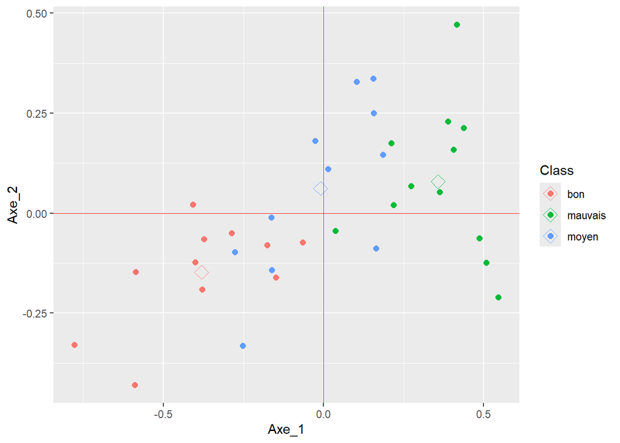

```r
# Graphe
graph <- AFD_graph1(Scores, label = T, center = T)
print(graph)
```

### 2.2 Distances

Nous calculons ensuite **les distances euclidiennes** de chaque individu aux différents centres de gravité de chaque groupe.

```r
# Distances
Sc <- as.matrix(Scores[,1:2])
distance <- sapply(c(1:nlevels(Y1)), function(i)
{
  gravity <- as.matrix(G_factoriel[i,2:3])
  gravity <- matrix(gravity, nrow = nrow(Scores), ncol = 2,  byrow = T)
  apply((Sc - gravity)^2 ,1,function(x) {return( sqrt(sum(x)))})
})

distance <- data.frame(distance) ; names(distance) <- levels(Y1)
```

## 3 Encapsulation

On construit une fonction (que nous appelerons **AFD_Classif**) et qui “encapsule” le code. Elle retournera :

- les centre de gravités
- les distances de chaque individu aux centre des classes (groupes).
- la comparaison entre la classification réalisée par l’AFD et le gold standard.
- la matrice de confusion.

```r
## Encapsulation
AFD_Classif <- function(Scores, Y1)
{
  # Centre de gravité
  G_factoriel  <- aggregate(Scores[,-3], by = list(Scores$Class ), mean)
  G_factoriel %>% kbl(digits=3, caption = "Centre de gravité des groupes sur le plan factoriel") %>%
    kable_styling(bootstrap_options = "striped", full_width = F, position = "center", latex_options = 'stripped') %>%  scroll_box( height = "150px")

  # Distances
  Sc <- as.matrix(Scores[,1:2])
  distance <- sapply(c(1:nlevels(Y1)), function(i)
  {
    gravity <- as.matrix(G_factoriel[i,2:3])
    gravity <- matrix(gravity, nrow = nrow(Scores), ncol = 2,  byrow = T)
    apply((Sc - gravity)^2 ,1,function(x) {return( sqrt(sum(x)))})
  })

  distance <- data.frame(distance)
  names(distance) <- levels(Y1)

  # Classification
  classif <- apply(distance,1, function(x) names(x)[which.min(x)])
  obs <- data.frame('classif' = factor(classif), 'gold_stardard' = Y1)

  # Matrice de confusion
  conf <- confusionMatrix(obs$classif, obs$gold_stardard)

  return(list(centroid  = G_factoriel,
              distance = distance,
              classif   = obs,
              confusion = conf))

}
```

## 4 Déploiement

Pour déployer le code, on utilisera le fichier *iris* fourni par défaut dans R.

```r
# Déploiement : iris
X1 <- iris[,1:4]
Y1 <- factor(iris[,5])

res_iris    <- MANOVA(X1,Y1)
afd_iris    <- AFD(X1,Y1, res_iris$SS_tot, res_iris$SS_Intra, res_iris$SS_Inter)
class_iris  <- AFD_Classif(afd_iris$Scores, Y1)
graph_iris  <- AFD_graph1(afd_iris$Scores, label = T, center = F)

class_iris$centroid %>% kbl(digits=3) %>%
  kable_styling(bootstrap_options = "striped", full_width = F, position = "center", latex_options = 'stripped') %>%  scroll_box( height = "150px")
```

| Group.1 | Axe_1 | Axe_2 |
| --- | --- | --- |
| setosa | -0.410 | -0.139 |
| versicolor | 0.084 | -0.006 |
| virginica | 0.326 | 0.145 |

```r
class_iris$distance %>% kbl(digits=3) %>%
  kable_styling(bootstrap_options = "striped", full_width = F, position = "center", latex_options = 'stripped') %>%  scroll_box( height = "150px")
```

| setosa | versicolor | virginica |
| --- | --- | --- |
| 0.013 | 0.517 | 0.793 |
| 0.065 | 0.541 | 0.823 |
| 0.066 | 0.563 | 0.844 |
| 0.070 | 0.546 | 0.828 |
| 0.021 | 0.522 | 0.798 |
| 0.113 | 0.444 | 0.709 |
| 0.038 | 0.545 | 0.824 |
| 0.006 | 0.511 | 0.789 |
| 0.114 | 0.580 | 0.864 |
| 0.055 | 0.532 | 0.814 |
| 0.060 | 0.483 | 0.754 |
| 0.017 | 0.511 | 0.790 |
| 0.079 | 0.556 | 0.838 |
| 0.146 | 0.632 | 0.916 |
| 0.112 | 0.503 | 0.764 |
| 0.179 | 0.465 | 0.714 |
| 0.089 | 0.498 | 0.764 |
| 0.017 | 0.510 | 0.786 |
| 0.120 | 0.432 | 0.698 |
| 0.057 | 0.494 | 0.765 |
| 0.057 | 0.458 | 0.734 |
| 0.052 | 0.488 | 0.760 |
| 0.091 | 0.603 | 0.880 |
| 0.055 | 0.457 | 0.735 |
| 0.047 | 0.470 | 0.750 |
| 0.056 | 0.507 | 0.789 |
| 0.029 | 0.483 | 0.761 |
| 0.023 | 0.497 | 0.773 |
| 0.005 | 0.512 | 0.789 |
| 0.047 | 0.522 | 0.804 |

[output cut: 120 more lines]

```r
class_iris$classif %>% kbl(digits=3) %>%
  kable_styling(bootstrap_options = "striped", full_width = F, position = "center", latex_options = 'stripped') %>%  scroll_box( height = "150px")
```

| classif | gold_stardard |
| --- | --- |
| setosa | setosa |
| setosa | setosa |
| setosa | setosa |
| setosa | setosa |
| setosa | setosa |
| setosa | setosa |
| setosa | setosa |
| setosa | setosa |
| setosa | setosa |
| setosa | setosa |
| setosa | setosa |
| setosa | setosa |
| setosa | setosa |
| setosa | setosa |
| setosa | setosa |
| setosa | setosa |
| setosa | setosa |
| setosa | setosa |
| setosa | setosa |
| setosa | setosa |
| setosa | setosa |
| setosa | setosa |
| setosa | setosa |
| setosa | setosa |
| setosa | setosa |
| setosa | setosa |
| setosa | setosa |
| setosa | setosa |
| setosa | setosa |
| setosa | setosa |

[output cut: 120 more lines]

```r
class_iris$confusion
```

```
## Confusion Matrix and Statistics
##
##             Reference
## Prediction   setosa versicolor virginica
##   setosa         50          0         0
##   versicolor      0         45         8
##   virginica       0          5        42
##
## Overall Statistics
##
##                Accuracy : 0.9133
##                  95% CI : (0.8564, 0.953)
##     No Information Rate : 0.3333
##     P-Value [Acc > NIR] : < 2.2e-16
##
##                   Kappa : 0.87
##
##  Mcnemar's Test P-Value : NA
##
## Statistics by Class:
##
##                      Class: setosa Class: versicolor Class: virginica
## Sensitivity                 1.0000            0.9000           0.8400
## Specificity                 1.0000            0.9200           0.9500
## Pos Pred Value              1.0000            0.8491           0.8936
## Neg Pred Value              1.0000            0.9485           0.9223
## Prevalence                  0.3333            0.3333           0.3333
## Detection Rate              0.3333            0.3000           0.2800
## Detection Prevalence        0.3333            0.3533           0.3133
## Balanced Accuracy           1.0000            0.9100           0.8950
```

==> On obtient une accuracy de 91%, ce qui est excellent. Le modèle réussit automatiquement, à identifier les différentes espèces d’iris.